# Managing data (second half) Data transformations

#Data transformations

Suppose you are considering the use of income as an input to your insurance model. The cost of living will vary from state to state, so what would be a high salary in one region could be barely enough to scrape by in another. Because of this, it might be more meaningful to normalize a customer’s income by the typical income in the area where they live. This is an example of a relatively simple (and common) transformation.

```r
median_income_table <- readRDS("median_income.RDS")
head(median_income_table)
```

|  | state_of_res | median_income |
| --- | --- | --- |
| 1 | Alabama | 21100 |
| 2 | Alaska | 32050 |
| 3 | Arizona | 26000 |
| 4 | Arkansas | 22900 |
| 5 | California | 25000 |
| 6 | Colorado | 32000 |

```r
median_income_table
```

| state_of_res | median_income |
| --- | --- |
| Alabama | 21100 |
| Alaska | 32050 |
| Arizona | 26000 |
| Arkansas | 22900 |
| California | 25000 |
| Colorado | 32000 |
| Connecticut | 36000 |
| Delaware | 29400 |
| District of Columbia | 40000 |
| Florida | 24000 |

[output cut: 41 more lines]

```r
library(dplyr)
customer_data<-read.csv("custdata.csv")
training_prepared <- left_join(customer_data, median_income_table, by="state_of_res")
training_prepared<-   mutate(training_prepared,   income_normalized = income/median_income)
```

```r
training_prepared
```

| custid | gender | is_employed | income | marital_status | health_ins | housing_type | recent_move | num_vehicles | age | state_of_res | gas_usage | median_income | income_normalized |
| --- | --- | --- | --- | --- | --- | --- | --- | --- | --- | --- | --- | --- | --- |
| 000006646_03 | Male | TRUE | 22000 | Never married | TRUE | Homeowner free and clear | FALSE | 0 | 24 | Alabama | 210 | 21100 | 1.0426540284 |
| 000007827_01 | Female | NA | 23200 | Divorced/Separated | TRUE | Rented | TRUE | 0 | 82 | Alabama | 3 | 21100 | 1.0995260664 |
| 000008359_04 | Female | TRUE | 21000 | Never married | TRUE | Homeowner with mortgage/loan | FALSE | 2 | 31 | Alabama | 40 | 21100 | 0.9952606635 |
| 000008529_01 | Female | NA | 37770 | Widowed | TRUE | Homeowner free and clear | FALSE | 1 | 93 | Alabama | 120 | 21100 | 1.7900473934 |
| 000008744_02 | Male | TRUE | 39000 | Divorced/Separated | TRUE | Rented | FALSE | 2 | 67 | Alabama | 3 | 21100 | 1.8483412322 |
| 000011466_01 | Male | NA | 11100 | Married | TRUE | Homeowner free and clear | FALSE | 2 | 76 | Alabama | 200 | 21100 | 0.5260663507 |
| 000015018_01 | Female | TRUE | 25800 | Married | FALSE | Rented | FALSE | 2 | 26 | Alabama | 3 | 21100 | 1.2227488152 |
| 000017314_02 | Female | NA | 34600 | Married | TRUE | Homeowner free and clear | FALSE | 2 | 73 | Alabama | 50 | 21100 | 1.6398104265 |
| 000017383_04 | Female | TRUE | 25000 | Never married | TRUE | Homeowner free and clear | FALSE | 5 | 27 | Alabama | 3 | 21100 | 1.1848341232 |
| 000017554_02 | Male | TRUE | 31200 | Married | TRUE | Homeowner with mortgage/loan | FALSE | 3 | 54 | Alabama | 20 | 21100 | 1.4786729858 |

[output cut: 9990 more lines]

```r
head(training_prepared[,c("income","median_income", "income_normalized")])
```

|  | income | median_income | income_normalized |
| --- | --- | --- | --- |
| 1 | 22000 | 21100 | 1.0426540 |
| 2 | 23200 | 21100 | 1.0995261 |
| 3 | 21000 | 21100 | 0.9952607 |
| 4 | 37770 | 21100 | 1.7900474 |
| 5 | 39000 | 21100 | 1.8483412 |
| 6 | 11100 | 21100 | 0.5260664 |

```r
summary(training_prepared$income_normalized)
```

Min. 1st Qu. Median Mean 3rd Qu. Max. -0.3223 0.4044 1.0000 1.5674 1.9615 46.5556

```r
summary(training_prepared$age)
```

Min. 1st Qu. Median Mean 3rd Qu. Max. 0.00 34.00 48.00 49.16 62.00 120.00

```r
library(ggplot2)
mean_age <- mean(training_prepared$age)
age_normalized <- training_prepared$age/mean_age
summary(age_normalized)
```

Min. 1st Qu. Median Mean 3rd Qu. Max. 0.0000 0.6916 0.9763 1.0000 1.2611 2.4408

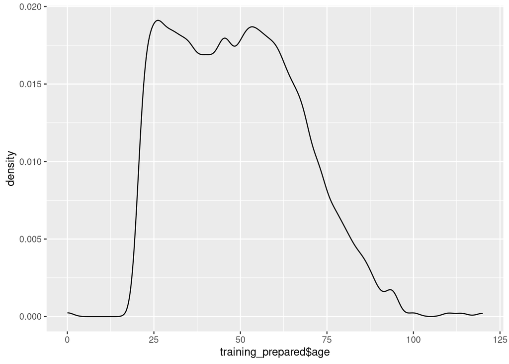

```r
ggplot(training_prepared,aes(training_prepared$age))+geom_density()
```

```r
class(age_normalized)
```

[1] “numeric”

```r
names(age_normalized)
```

NULL

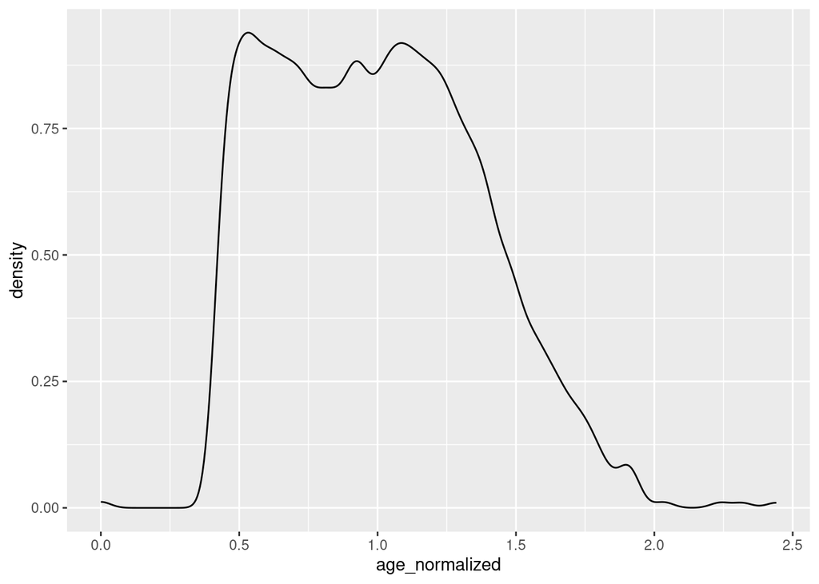

```r
ggplot(mapping=aes(x=age_normalized))+geom_density()
```

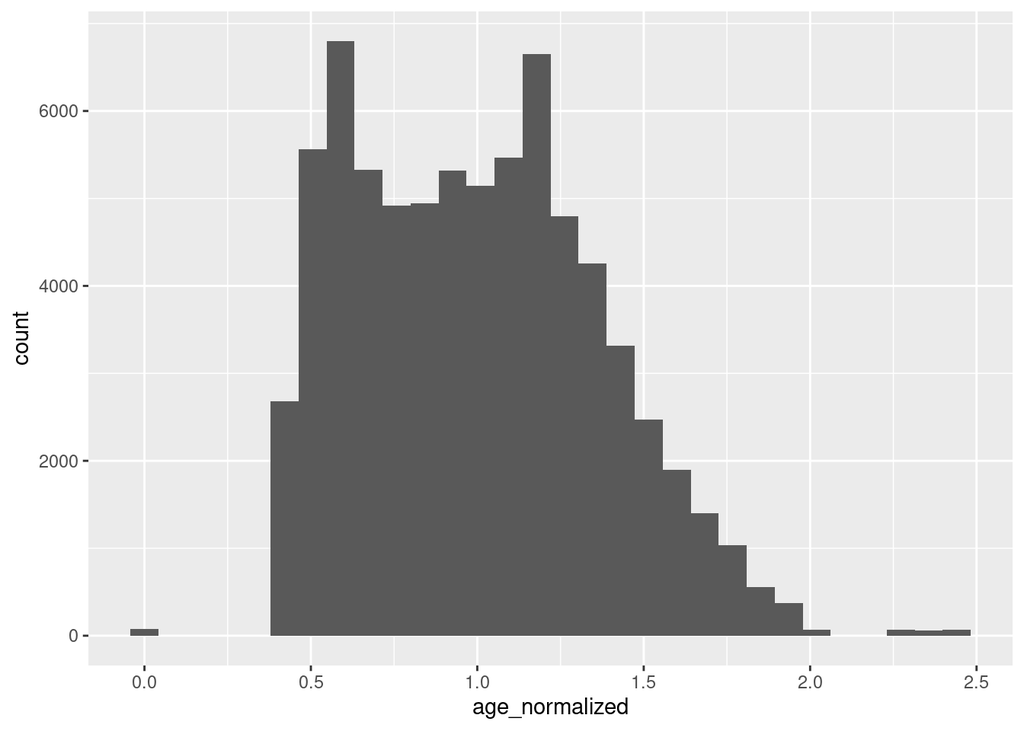

```r
ggplot(mapping=aes(x=age_normalized))+geom_histogram()
```

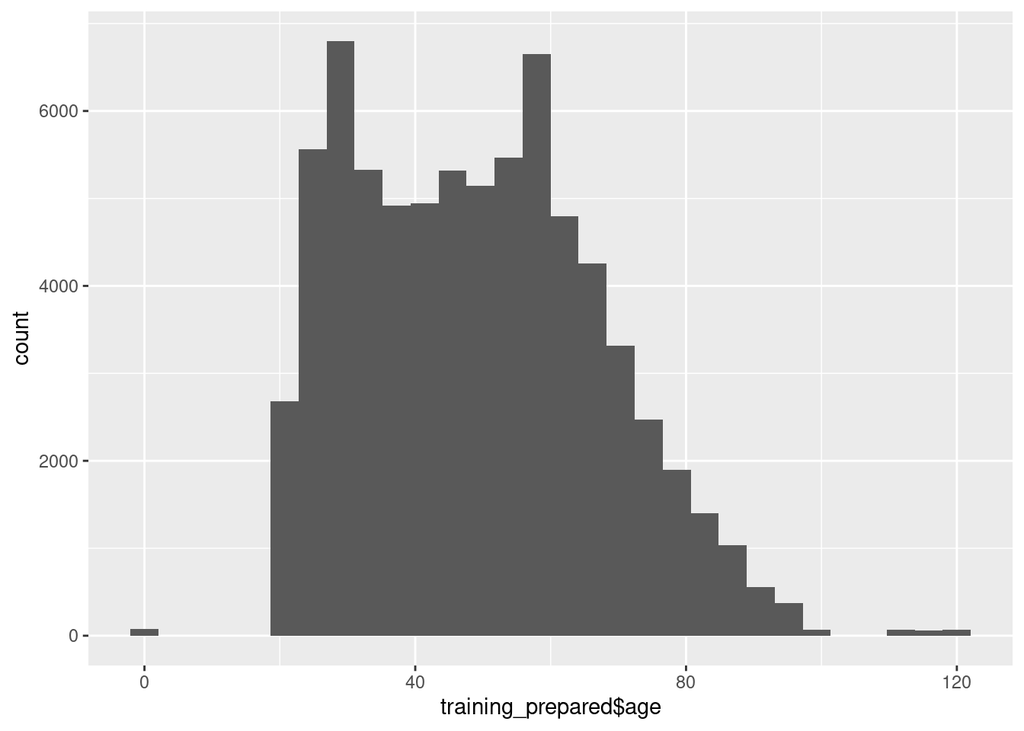

```r
ggplot(mapping=aes(x=training_prepared$age))+geom_histogram()
```

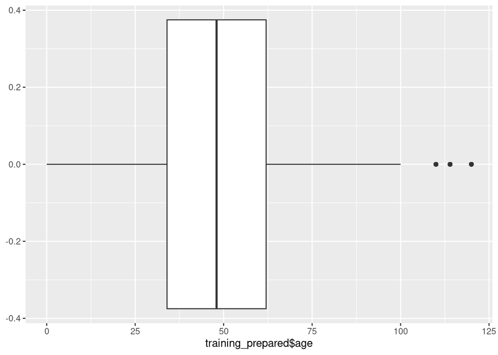

```r
ggplot(mapping=aes(x=training_prepared$age))+geom_boxplot()
```

### Benefits

#Centering and scaling

```r
mean_age <- mean(training_prepared$age)
sd_age <- sd(training_prepared$age)
training_prepared$scaled_age <- (training_prepared$age-mean_age) / sd_age
head(training_prepared)
```

|  | custid | gender | is_employed | income | marital_status | health_ins | housing_type | recent_move | num_vehicles | age | state_of_res | gas_usage | median_income | income_normalized | scaled_age |
| --- | --- | --- | --- | --- | --- | --- | --- | --- | --- | --- | --- | --- | --- | --- | --- |
| 1 | 000006646_03 | Male | TRUE | 22000 | Never married | TRUE | Homeowner free and clear | FALSE | 0 | 24 | Alabama | 210 | 21100 | 1.0426540 | -1.3916352 |
| 2 | 000007827_01 | Female | NA | 23200 | Divorced/Separated | TRUE | Rented | TRUE | 0 | 82 | Alabama | 3 | 21100 | 1.0995261 | 1.8158229 |
| 3 | 000008359_04 | Female | TRUE | 21000 | Never married | TRUE | Homeowner with mortgage/loan | FALSE | 2 | 31 | Alabama | 40 | 21100 | 0.9952607 | -1.0045282 |
| 4 | 000008529_01 | Female | NA | 37770 | Widowed | TRUE | Homeowner free and clear | FALSE | 1 | 93 | Alabama | 120 | 21100 | 1.7900474 | 2.4241339 |
| 5 | 000008744_02 | Male | TRUE | 39000 | Divorced/Separated | TRUE | Rented | FALSE | 2 | 67 | Alabama | 3 | 21100 | 1.8483412 | 0.9863079 |
| 6 | 000011466_01 | Male | NA | 11100 | Married | TRUE | Homeowner free and clear | FALSE | 2 | 76 | Alabama | 200 | 21100 | 0.5260664 | 1.4840169 |

- **Centers the data around zero**
  - After transformation, the mean of `scaled_age` will be 0.
  - This removes the bias from large positive or negative raw values.
    - **Puts variables on the same scale**
  - After scaling, the standard deviation will be 1.
  - This is important in models (like regression, k-means, PCA, neural networks) that are sensitive to variable magnitudes.
  - Example: Without scaling, a variable measured in **years** and another in **millimeters** would have vastly different ranges, skewing results.
    - **Improves numerical stability**
  - Large values can cause computational issues in algorithms like gradient descent.

```r
subset(training_prepared,abs(age-mean_age)<sd_age) %>% select(age, scaled_age) %>% head()
```

|  | age | scaled_age |
| --- | --- | --- |
| 5 | 67 | 0.9863079 |
| 10 | 54 | 0.2673949 |
| 11 | 61 | 0.6545019 |
| 12 | 64 | 0.8204049 |
| 13 | 57 | 0.4332979 |
| 14 | 55 | 0.3226959 |

```r
subset(training_prepared,abs(age-mean_age)>sd_age) %>% select(age, scaled_age) %>% head()
```

|  | age | scaled_age |
| --- | --- | --- |
| 1 | 24 | -1.391635 |
| 2 | 82 | 1.815823 |
| 3 | 31 | -1.004528 |
| 4 | 93 | 2.424134 |
| 6 | 76 | 1.484017 |
| 7 | 26 | -1.281033 |

```r
training_prepared |> head()
```

|  | custid | gender | is_employed | income | marital_status | health_ins | housing_type | recent_move | num_vehicles | age | state_of_res | gas_usage | median_income | income_normalized | scaled_age |
| --- | --- | --- | --- | --- | --- | --- | --- | --- | --- | --- | --- | --- | --- | --- | --- |
| 1 | 000006646_03 | Male | TRUE | 22000 | Never married | TRUE | Homeowner free and clear | FALSE | 0 | 24 | Alabama | 210 | 21100 | 1.0426540 | -1.3916352 |
| 2 | 000007827_01 | Female | NA | 23200 | Divorced/Separated | TRUE | Rented | TRUE | 0 | 82 | Alabama | 3 | 21100 | 1.0995261 | 1.8158229 |
| 3 | 000008359_04 | Female | TRUE | 21000 | Never married | TRUE | Homeowner with mortgage/loan | FALSE | 2 | 31 | Alabama | 40 | 21100 | 0.9952607 | -1.0045282 |
| 4 | 000008529_01 | Female | NA | 37770 | Widowed | TRUE | Homeowner free and clear | FALSE | 1 | 93 | Alabama | 120 | 21100 | 1.7900474 | 2.4241339 |
| 5 | 000008744_02 | Male | TRUE | 39000 | Divorced/Separated | TRUE | Rented | FALSE | 2 | 67 | Alabama | 3 | 21100 | 1.8483412 | 0.9863079 |
| 6 | 000011466_01 | Male | NA | 11100 | Married | TRUE | Homeowner free and clear | FALSE | 2 | 76 | Alabama | 200 | 21100 | 0.5260664 | 1.4840169 |

Ploting density function for income

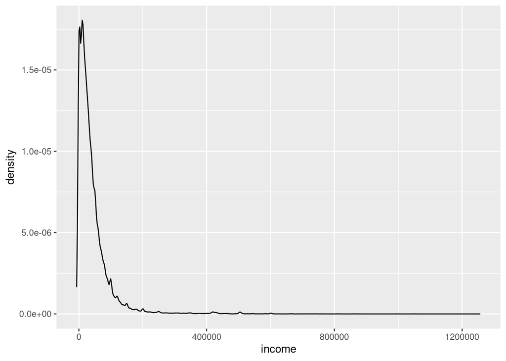

```r
ggplot(customer_data,aes(x=income))+geom_density()
```

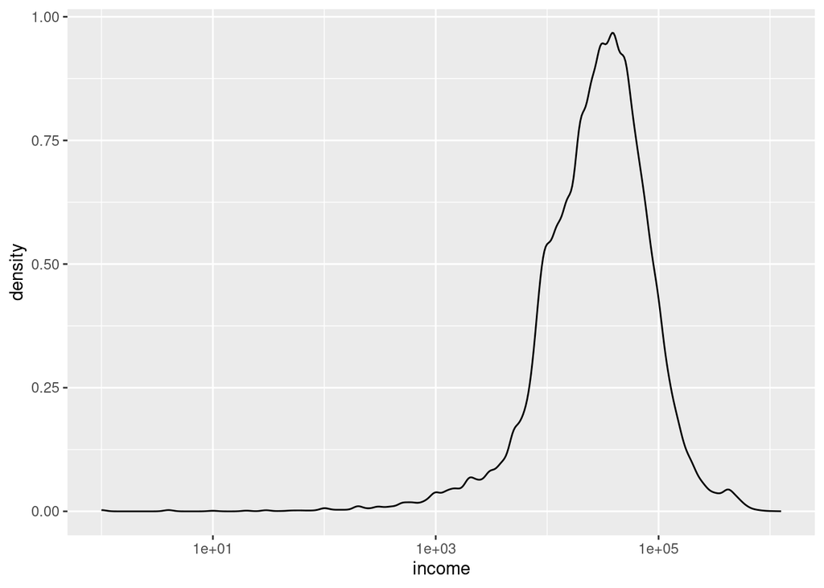

```r
ggplot(customer_data,aes(x=income))+geom_density()+scale_x_log10()
```

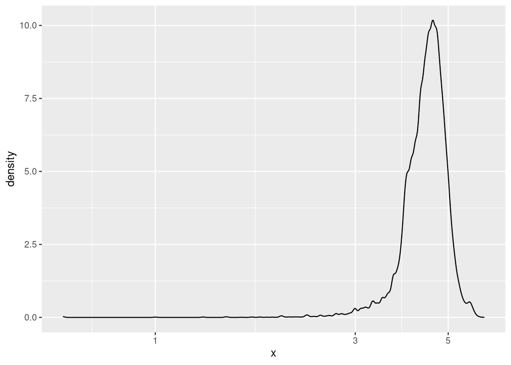

```r
signedlog10 <- function(x) {
ifelse(abs(x) <= 1, 0, sign(x)*log10(abs(x)))
}

x=signedlog10(customer_data$income)
ggplot(mapping=aes(x=x))+geom_density()+scale_x_log10()
```

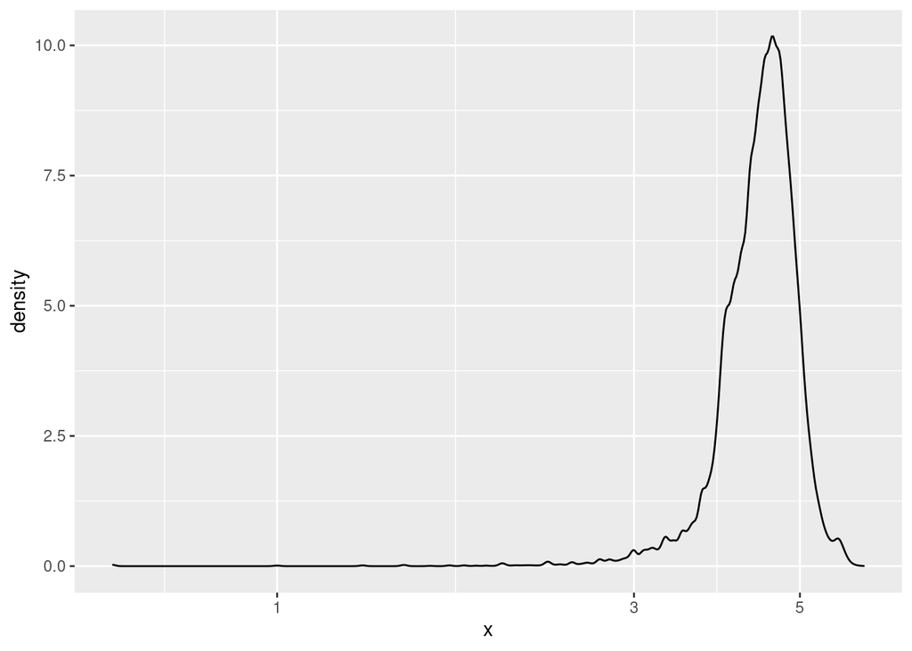

```r
ordlog<-function(x){
  ifelse(x == 0, 0, sign(x)*log10(abs(x)))
}
x=ordlog(customer_data$income)
ggplot(mapping=aes(x=x))+geom_density()+scale_x_log10()
```

It’s also generally a good idea to log transform data containing values that range over several orders of magnitude, for example, the population of towns and cities, which may range from a few hundred to several million. One reason for this is that modeling techniques often have a difficult time with very wide data ranges. Another reason is because such data often comes from multiplicative processes rather than from an additive one, so log units are in some sense more natural.